# Part II - (FORD GOBIKE DATASET EXPLORATION)

## by (Frank Emmanuel Azibolanari)

## Investigation Overview

> I n this project, we want to demonstrate the relevance of data visualization in the data analysis process. Firstly, I used python modules such as NumPy, pandas, Matplotlib, and Seaborn to wrangle the data and create visualizations. Now this phase presents a short presentation that will sumarize interesting discovery from our dataset. In this presentation, the following questions will be answered;
> - How long does the average trip take?
> - When are most busiest start times during the day and during the week?
> - How does bike sharing, user type and gender, day of the week and start time during the day influnce trip duration?
> - How does the day of the week and time of the day influence number of rides based on gender and user type.

## Dataset Overview

> This data set includes information about individual rides made in a bike-sharing system covering the greater San Francisco Bay area. The dataset comprises of 183412 rows and 16 columns. The columns are;
- duration_sec
- start_time
- end_time
- start_station_id
- start_station_name
- start_station_latitude
- start_station_longitude
- end_station_id
- end_station_name
- end_station_latitude
- end_station_longitude
- bike_id
- user_type
- member_birth_year
- member_gender
- bike_share_for_all_trip

In addition to these columns, I created 3 extra columns to hold the month, day of the week, and hour of the day, of which I extracted from the 'start_time' column. Some of the datatypes in this dataset had to be changed to a more appropriate datatype for analysis.

## Part 1

> Let's take a look at the variables individually; The variables of interest are duration, bike sharing, user type and gender, days of the week and time during the day.

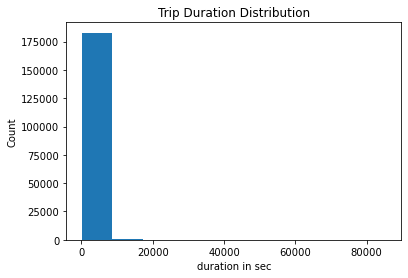

Notice that most ride durations fall between 0 to somewhere less than 20,000 secs, but there are few outliers reaching upto 80,000. However this doesn't really tell much, so I employed the use of a logarithmic scale to dive deeper and see how the distribution spreads.

```
mean of duration_sec is: 726.078435434977
```

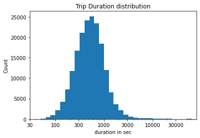

Now we can see in more details the distribution of the duration time. we observed that the log plot is symentrical and unimodal, and most of the distribution of the duration falls somewhere within 60 to 10,000 seconds, but we can see some outliers past 10,000 upto 30,000 and beyond. Because this plot is symentrical and unimodal, the mean is located at the centre of the distribution... Looking a the plot, the mean is somewhere around 700 secs. However by using the mean funtion we can see the exact average duration is approximately 726 seconds.

To answer our first question, the average trip duration is 726 seconds.

```
The user type count:  Subscriber    163544
Customer       19868
Name: user_type, dtype: int64
```

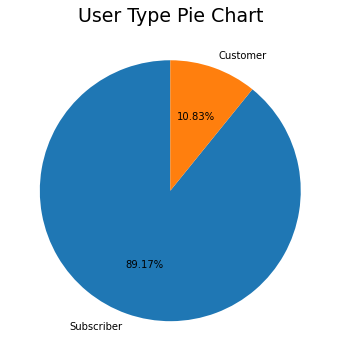

On the chart we can see that majority of the users are subscribers which is about 89.17% of the total users with a count of 163,544, and the customers taking just 10.83% of the total users and are 19,868 in number.

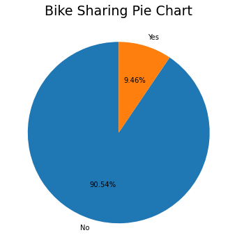

Most of the riders did not share bikes during their trips, about 90.54% did not share. we can see that only 9.46% chose to share bike.

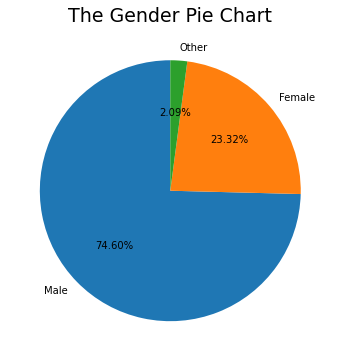

We can see that majority of the riders are Men, followed by women and other gender. Again we see a huge disparity here, The majority of riders are men taking about 74.60%, women in the second place with just 23.32%, the other genders even lesser with just 2.09%.

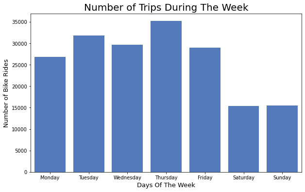

We can see that there is lesser trips taken during the weekends, and majority of the trips are taken during the week. Notice there are lesser number of trips taken on Saturdays and Sundays. And the days with highest number of trips taken are Thursday, Tuesday and Wednesday, Friday, and Monday respectively which are weekdays. This answers the second part of the second question set earlier, 'When are most trips taken during the week?'.

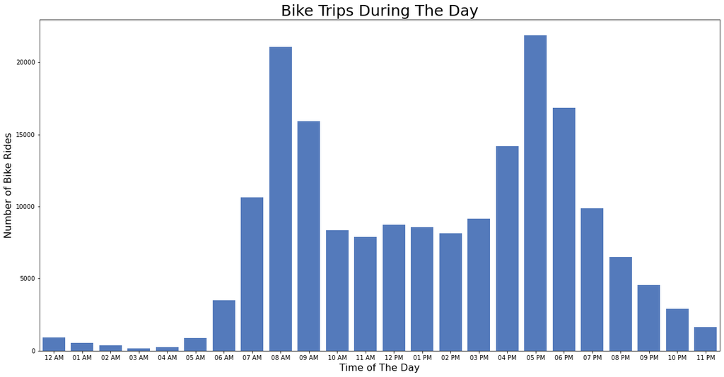

In the plot we see when the bike bikers started their trips during the day. We observed lower activity during the early hours of the day, i.e from 12am to 5am. At 6am, we start to notice more people have started their trip, the growth in number increases rapidly to a peak at 8am, then declines at 9am, stays fairly stable throughout the afternoon, and during the evening around 4pm, we start to obeserve inscrease in the number of rides, that rapidly reaches the peak of the day at 5pm, then consistently declines towards the end of the day at night. This answers the first part of the second question set earlier, 'When are most trips taken during the day?'.

## Part 2

> Now how does the average trip duration affect these other variables? By sheding more light on this, we'll be able to answer the third question.

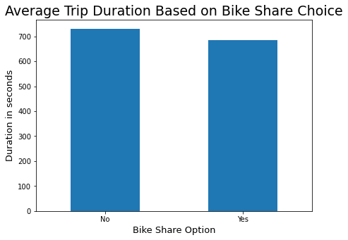

The average duration of both shared biking duration and not shared are pretty close. Although the average duration of not shared bike trips is a little higher. Regardless, I speculate that its is very likely sharing bike or not doesn't really influence the duration of the trip.

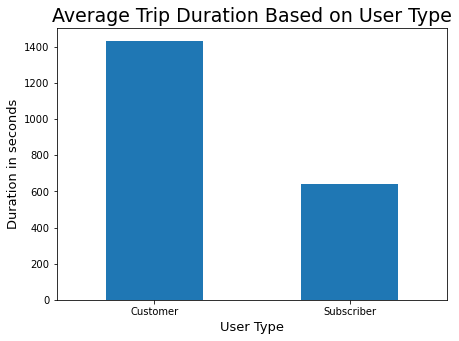

We can see the that Customers significantly spend time biking than subscribers generally.

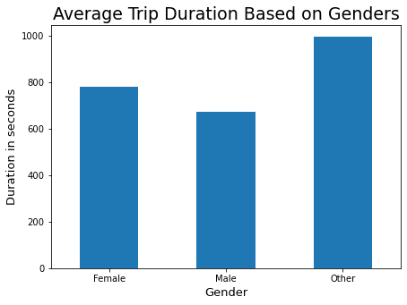

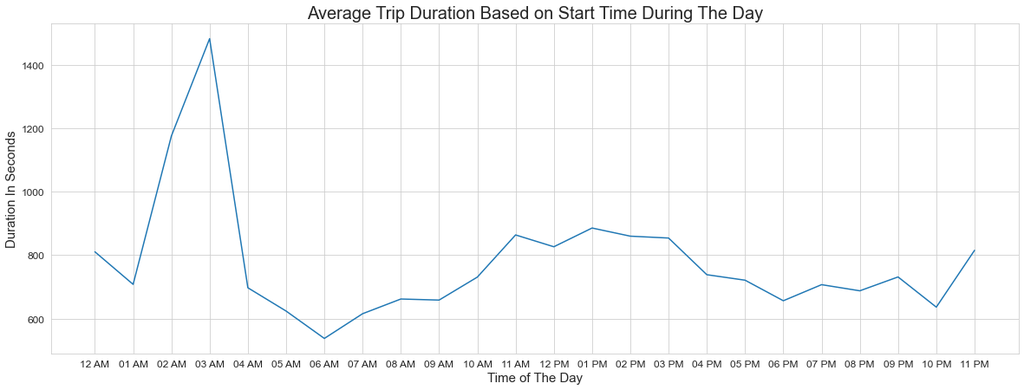

We can see that in contrast to the number of rides during the day, those who started biking in the early part of the day from 2am to 3am had the highest trip duration probably people who do it for hardcore excercise or training, then the avgerage duration declines drastically from 4am till 6am, then the average duration starts to increase from 7am gradually till 11am and and stay staggering throughout the afternoon, and starts declining by 4pm towards the evening.

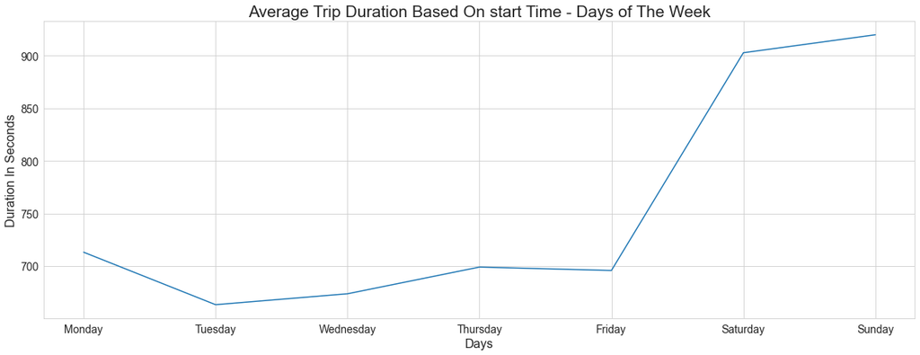

here we can see that trip duration were longer on the weekends and significantly lower on the week days. This makes sense to me, as I imagine a lot of trips during the week are for offical movements such as school, work, etc hence people might be in a hurry to reach their destinations, however during the weekends, I imagine people ride for recreation, excercise, training etc, so they may not be in a rush to get to their distination.

## Part 3

> Let's answer the final question... 'How does the day of the week and time of the day influence number of rides based on gender and user type?'

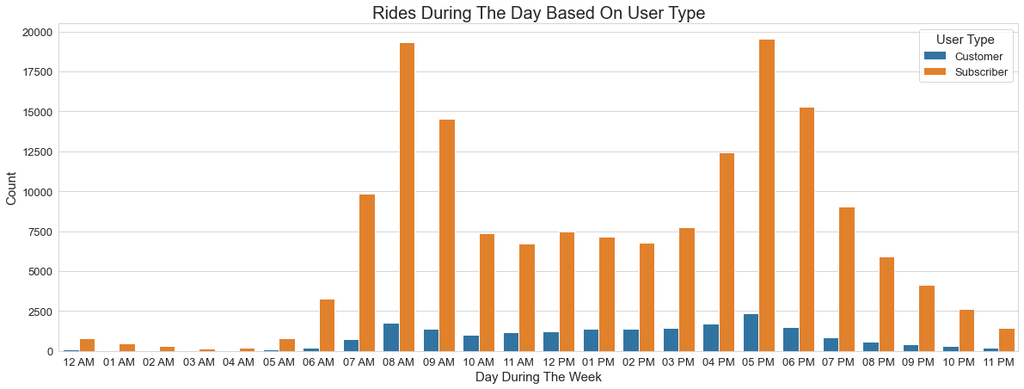

There are barely any customers riding in the early hours of the day. It has always been the case that subscribers are the majority so no surprises here, but notice the trend in customers... They are mostly active from 8am to 6pm, this makes me speculate that most of the customers maybe students,workers etc as they there are more rides seen during convention "official working hours"... This is marely a speculation, but I found it interesting.

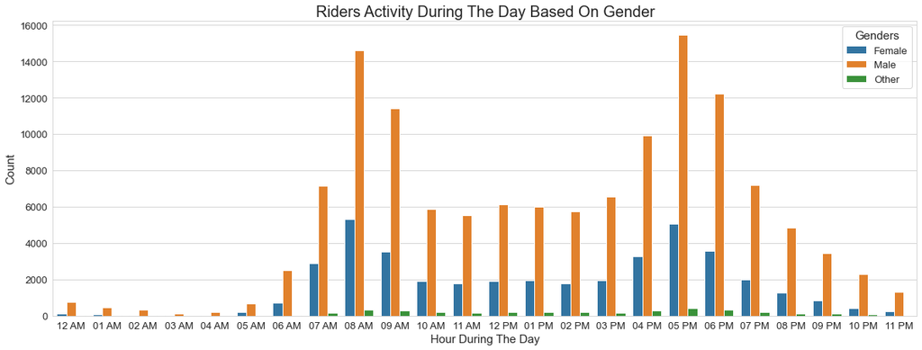

During the early hours of the day there are barely any gender riding other than the male, however this changes in the later part of the morning from 6am, we begin to notice a significant amount of females, then by 7am the other genders join in till 9pm, females continue till as a late as 11pm.

## Conclusion

In conclusion I'll summmarize the answer to those questions posed at the beginning of this presentation.

- The average duration is 726 seconds.
- The weekdays are the most busiest time during the week, with lesser activity in the weekends. During the day, the most busiest times are 8am in the morning and 5pm in the late afternoon.
- Bike sharing doesn't seem to strongly determine trip duration. Customers spend more time in trips than subscribers. The other gender spend the most time during trips, followed by women, and men spend the least time on their trips. Riders that start between 2am to 3am spent the longest time during their trips, followed by users who started bewtween 11am to 3pm. Ironically, during the week riders spent the most time on their trips during the weekends and lesser during weekdays, cause there were more riders during the week and less during the weekends.
- Subscribers are more active during all times of the day than customers. Also, Men are the most active during all times of the day.